# Neuropilin-2

## Figure 4: Best-cluster predicted contact maps over the two true folds.

Predicted contact maps (MSA-Transformer) for the clusters best matching each fold, over the true contacts of fold 1 (upper triangle) and fold 2 (lower). Divergent contacts between clusters are the contact-level signature of fold-switching.

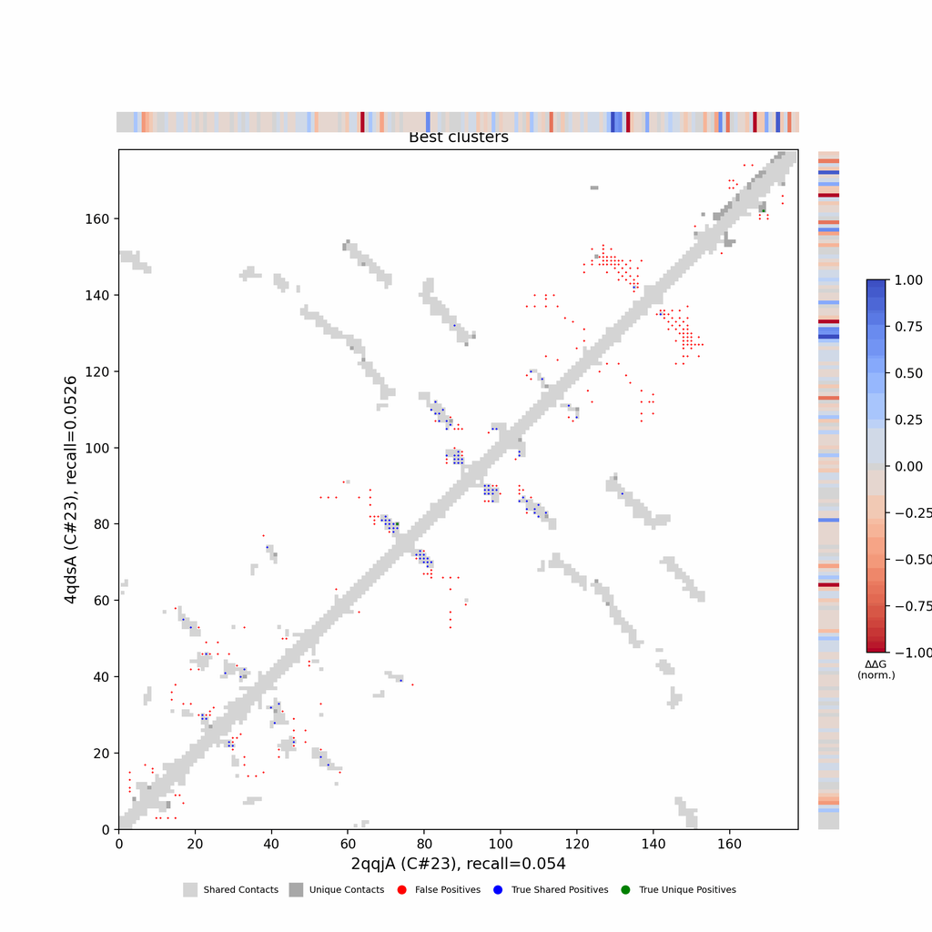

## Figure 5: Per-residue ΔΔG fold-preference contribution

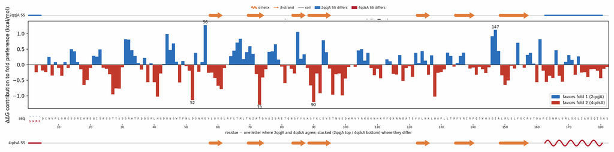

**More figures**

## Figure 6: Deep-MSA contact map panel / Best clusters contact map panel

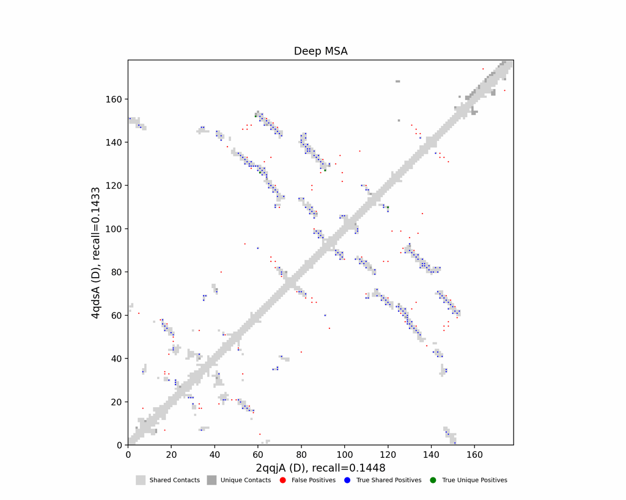

Deep-MSA contact map panel

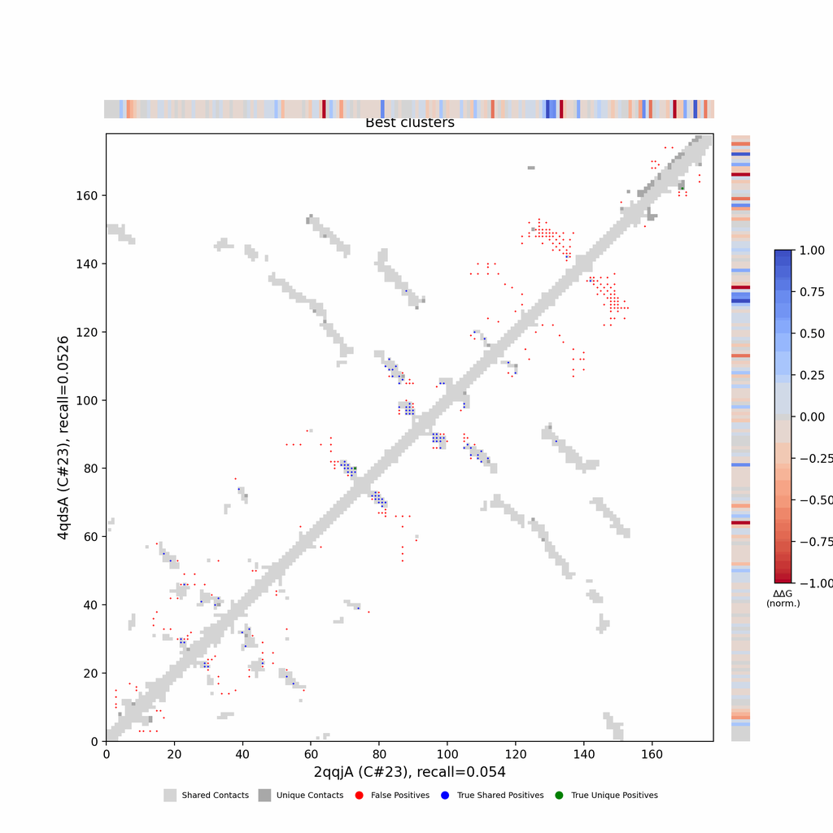

Best clusters contact map panel

## Figure 7: All clusters contact-map mosaic (small multiples).

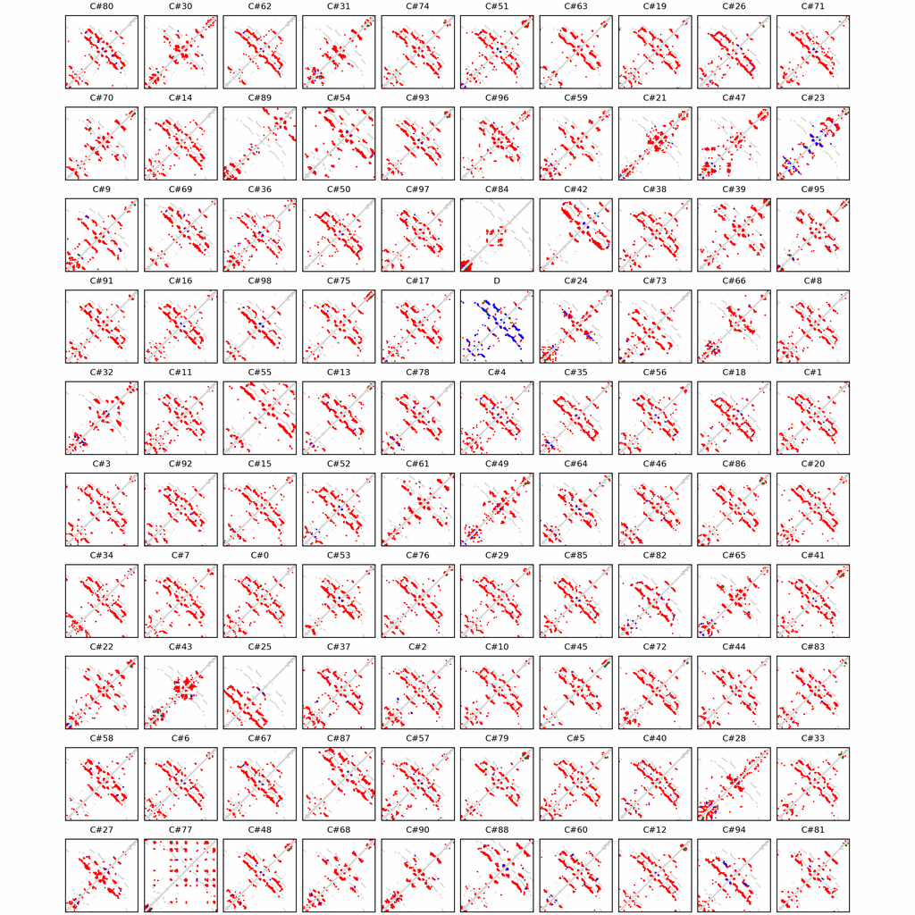

## Figure 8: Phylo null: tree with shuffled cluster fold labels.

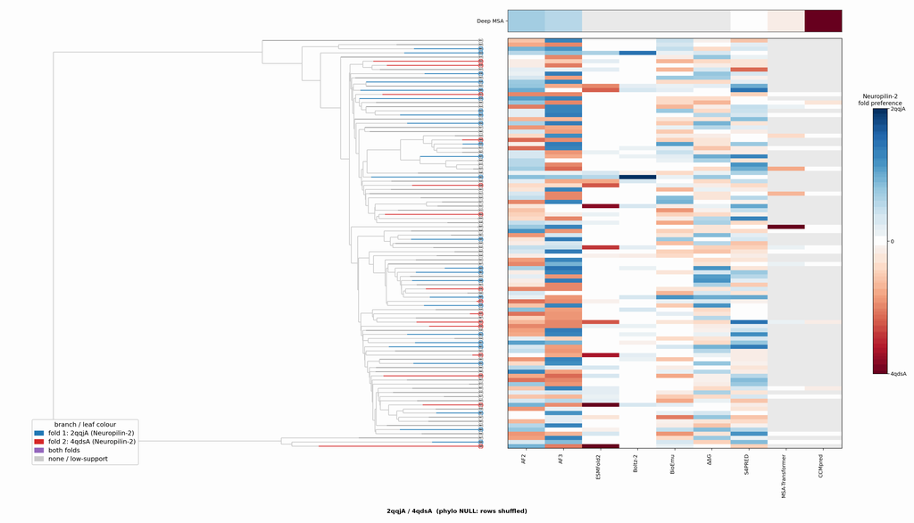

## Cluster metrics table

Per-cluster metrics underlying the figures above.

| cluster | n | neff | AF2_TM1 | AF2_TM2 | AF3_TM1 | AF3_TM2 | RE-MSAT-COM | RE-MSAT1 | RE-MSAT2 | ESM_SEQIDS | ESM_TM1 | ESM_TM2 | ΔΔG_Bias | ΔΔG_Bias_std | ΔΔG_frac_F1 | Boltz2_pref | S4PRED_pref | CCMpred_pref | BioEmu_pref |
| --- | --- | --- | --- | --- | --- | --- | --- | --- | --- | --- | --- | --- | --- | --- | --- | --- | --- | --- | --- |
| Deep | - | - | 0.98 | 0.89 | 0.98 | 0.88 | 0.47 | 0.43 | 0.47 | - | - | - | - | - | - | - | -0.0 | -0.06 | - |
| 000 | 934.0 | 637.0 | 0.86 | 0.87 | 0.58 | 0.9 | 0.0 | 0.01 | 0.01 | 001; 001; 006; 006; 003; 003; 007; 007; 004; 004 | 0.55 ± 0.03 | 0.81 ± 0.05 | -73.47 | 31.69 | 0.0 | -0.19 | 0.02 | -0.01 | -0.12 |
| 001 | 778.0 | 491.0 | 0.57 | 0.78 | 0.97 | 0.89 | 0.01 | 0.01 | 0.01 | 008; 008; 001; 001; 004; 004; 002; 002; 007; 010 | 0.55 ± 0.06 | 0.80 ± 0.04 | -61.95 | 30.52 | 0.1 | -0.23 | 0.03 | -0.0 | -0.1 |
| 002 | 513.0 | 304.0 | 0.38 | 0.59 | 0.48 | 0.8 | 0.01 | 0.01 | 0.01 | 002; 005; 002; 005; 001; 001; 003; 003; 006; 006 | 0.56 ± 0.05 | 0.79 ± 0.04 | -63.33 | 29.38 | 0.0 | -0.14 | 0.08 | -0.01 | -0.08 |
| 003 | 511.0 | 356.0 | 0.28 | 0.38 | 0.97 | 0.87 | 0.01 | 0.0 | 0.01 | 004; 004; 001; 002; 002; 001; 003; 005; 005; 003 | 0.54 ± 0.04 | 0.79 ± 0.04 | -28.19 | 26.38 | 0.1 | -0.22 | 0.03 | 0.0 | -0.1 |
| 004 | 494.0 | 359.0 | 0.81 | 0.89 | 0.98 | 0.89 | 0.02 | 0.02 | 0.02 | 008; 008; 003; 003; 002; 002; 006; 006; 001; 001 | 0.57 ± 0.08 | 0.82 ± 0.02 | -68.61 | 33.74 | 0.0 | -0.24 | 0.01 | -0.0 | -0.13 |
| 005 | 475.0 | 366.0 | 0.89 | 0.9 | 0.97 | 0.89 | 0.0 | 0.0 | 0.0 | 003; 003; 001; 001; 005; 002; 002; 005; 004; 004 | 0.57 ± 0.05 | 0.79 ± 0.03 | -59.0 | 33.83 | 0.0 | -0.22 | 0.02 | 0.0 | -0.1 |
| 006 | 327.0 | 200.0 | 0.4 | 0.65 | 0.45 | 0.72 | 0.01 | 0.01 | 0.01 | 004; 004; 005; 005; 006; 006; 001; 001; 009; 009 | 0.54 ± 0.04 | 0.82 ± 0.02 | -58.1 | 35.3 | 0.1 | -0.17 | 0.06 | 0.0 | -0.19 |
| 007 | 309.0 | 198.0 | 0.56 | 0.83 | 0.91 | 0.9 | 0.0 | 0.0 | 0.01 | 002; 002; 006; 006; 001; 001; 009; 004; 004; 009 | 0.54 ± 0.05 | 0.81 ± 0.01 | -56.86 | 36.11 | 0.0 | -0.2 | 0.02 | 0.0 | -0.1 |
| 008 | 303.0 | 235.0 | 0.7 | 0.78 | 0.91 | 0.9 | 0.0 | 0.0 | 0.0 | 003; 003; 004; 004; 005; 005; 001; 001; 008; 008 | 0.57 ± 0.08 | 0.78 ± 0.04 | -65.23 | 31.77 | 0.0 | -0.2 | 0.05 | -0.0 | -0.09 |
| 009 | 288.0 | 160.0 | 0.91 | 0.86 | 0.59 | 0.89 | 0.01 | 0.01 | 0.01 | 001; 001; 004; 004; 002; 002; 007; 005; 003; 003 | 0.50 ± 0.04 | 0.79 ± 0.02 | -60.65 | 32.15 | 0.0 | -0.13 | 0.01 | 0.0 | -0.1 |
| 010 | 277.0 | 185.0 | 0.68 | 0.86 | 0.97 | 0.9 | 0.0 | 0.0 | 0.0 | 001; 001; 005; 005; 004; 004; 003; 006; 006; 003 | 0.52 ± 0.01 | 0.77 ± 0.02 | -54.27 | 34.73 | 0.0 | -0.15 | 0.02 | 0.0 | -0.1 |
| 011 | 259.0 | 187.0 | 0.57 | 0.86 | 0.96 | 0.89 | 0.0 | 0.0 | 0.0 | 009; 009; 005; 005; 002; 002; 001; 004; 001; 004 | 0.49 ± 0.03 | 0.80 ± 0.01 | -69.66 | 31.54 | 0.0 | -0.08 | 0.02 | -0.0 | -0.09 |
| 012 | 235.0 | 172.0 | 0.82 | 0.88 | 0.58 | 0.89 | 0.01 | 0.02 | 0.01 | 001; 001; 005; 005; 004; 004; 006; 006; 003; 003 | 0.50 ± 0.03 | 0.79 ± 0.03 | -57.12 | 32.48 | 0.0 | -0.21 | 0.02 | 0.0 | -0.1 |
| 013 | 215.0 | 119.0 | 0.58 | 0.84 | 0.57 | 0.89 | 0.01 | 0.0 | 0.01 | 001; 001; 009; 009; 004; 004; 002; 002; 003; 003 | 0.70 ± 0.16 | 0.82 ± 0.04 | -49.3 | 34.48 | 0.0 | -0.19 | 0.0 | 0.0 | -0.1 |
| 014 | 211.0 | 97.0 | 0.6 | 0.87 | 0.98 | 0.89 | 0.0 | 0.0 | 0.0 | 004; 004; 003; 003; 002; 002; 007; 007; 001; 001 | 0.54 ± 0.04 | 0.79 ± 0.03 | -54.92 | 38.84 | 0.0 | -0.18 | 0.04 | 0.0 | -0.13 |
| 015 | 211.0 | 132.0 | 0.82 | 0.84 | 0.54 | 0.89 | 0.0 | 0.0 | 0.0 | 001; 001; 002; 002; 008; 007; 003; 003; 008; 007 | 0.49 ± 0.03 | 0.77 ± 0.02 | -61.14 | 38.83 | 0.0 | -0.19 | 0.06 | 0.0 | -0.1 |
| 016 | 202.0 | 82.0 | 0.21 | 0.27 | 0.26 | 0.33 | 0.0 | 0.01 | 0.0 | 008; 008; 003; 003; 002; 002; 001; 001; 006; 006 | 0.59 ± 0.09 | 0.79 ± 0.03 | -65.51 | 38.08 | 0.0 | -0.08 | 0.0 | 0.0 | -0.06 |
| 017 | 201.0 | 121.0 | 0.34 | 0.55 | 0.4 | 0.67 | 0.01 | 0.02 | 0.01 | 009; 009; 004; 004; 005; 005; 003; 003; 002; 002 | 0.52 ± 0.03 | 0.76 ± 0.02 | -64.57 | 31.67 | 0.0 | -0.23 | 0.03 | 0.0 | -0.08 |
| 018 | 188.0 | 109.0 | 0.3 | 0.48 | 0.47 | 0.69 | 0.01 | 0.01 | 0.01 | - | - | - | -52.65 | 33.29 | 0.0 | -0.23 | 0.01 | - | -0.06 |
| 019 | 187.0 | 69.0 | 0.87 | 0.89 | 0.97 | 0.89 | 0.0 | 0.0 | 0.0 | - | - | - | -63.03 | 31.29 | 0.0 | -0.21 | 0.03 | - | -0.12 |
| 020 | 187.0 | 127.0 | 0.85 | 0.9 | 0.58 | 0.9 | 0.0 | 0.0 | 0.01 | - | - | - | -56.31 | 34.7 | 0.0 | -0.14 | 0.04 | - | -0.06 |
| 021 | 186.0 | 26.0 | 0.24 | 0.23 | 0.52 | 0.83 | 0.0 | 0.0 | 0.0 | - | - | - | -48.4 | 28.8 | 0.0 | -0.25 | 0.01 | - | -0.05 |
| 022 | 173.0 | 95.0 | 0.26 | 0.4 | 0.36 | 0.6 | 0.01 | 0.01 | 0.01 | - | - | - | -64.62 | 31.88 | 0.0 | -0.2 | 0.01 | - | -0.12 |
| 023 | 173.0 | 18.0 | 0.24 | 0.34 | 0.22 | 0.35 | 0.06 | 0.04 | 0.06 | - | - | - | -37.58 | 35.1 | 0.0 | -0.12 | -0.02 | - | -0.09 |
| 024 | 171.0 | 17.0 | 0.2 | 0.25 | 0.78 | 0.78 | 0.0 | 0.0 | 0.0 | - | - | - | -37.8 | 25.17 | 0.0 | 0.0 | 0.02 | - | -0.06 |
| 025 | 169.0 | 110.0 | 0.79 | 0.86 | 0.6 | 0.89 | 0.01 | 0.01 | 0.01 | - | - | - | -12.94 | 20.49 | 0.1 | -0.15 | 0.07 | - | -0.09 |
| 026 | 160.0 | 126.0 | 0.69 | 0.83 | 0.98 | 0.88 | 0.02 | 0.02 | 0.02 | - | - | - | -59.52 | 32.9 | 0.0 | -0.18 | 0.05 | - | -0.05 |
| 027 | 158.0 | 33.0 | 0.52 | 0.77 | 0.59 | 0.89 | 0.0 | 0.0 | 0.0 | - | - | - | -28.18 | 35.66 | 0.1 | -0.28 | 0.03 | - | -0.09 |
| 028 | 156.0 | 10.0 | 0.19 | 0.25 | 0.19 | 0.29 | 0.0 | 0.0 | 0.0 | - | - | - | -25.39 | 17.44 | 0.0 | -0.2 | 0.0 | - | -0.09 |

[output cut: 70 more lines]